# Assessment of the Flathead sole-Bering flounder Stock in the Bering Sea and Aleutian Islands

# Figures

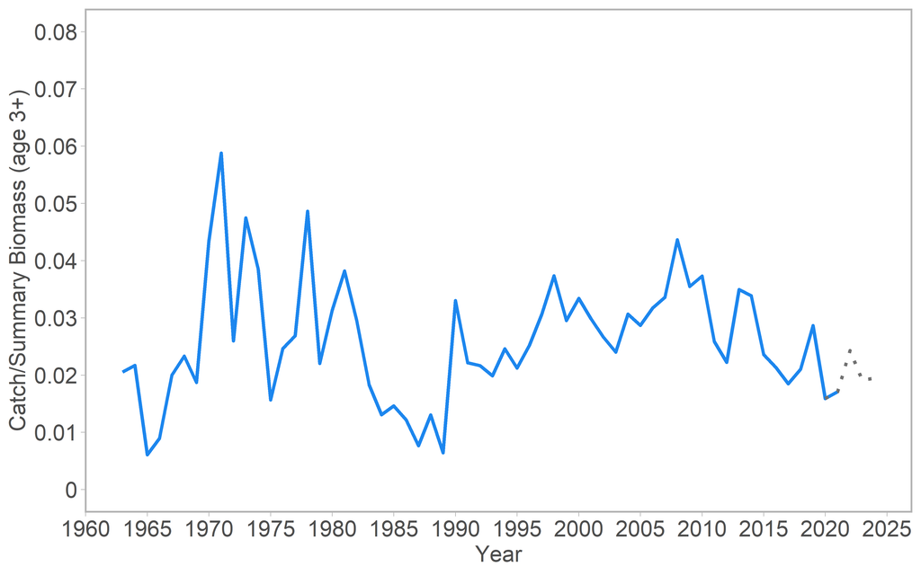

**Figure 1**. Catch to total biomass ratio using total biomass for age 3+ individuals for flathead sole in the Bering Sea and Aleutian Islands. Dotted grey lines represent observed catches for 2021 and projected catches for 2022 and 2023-2024.

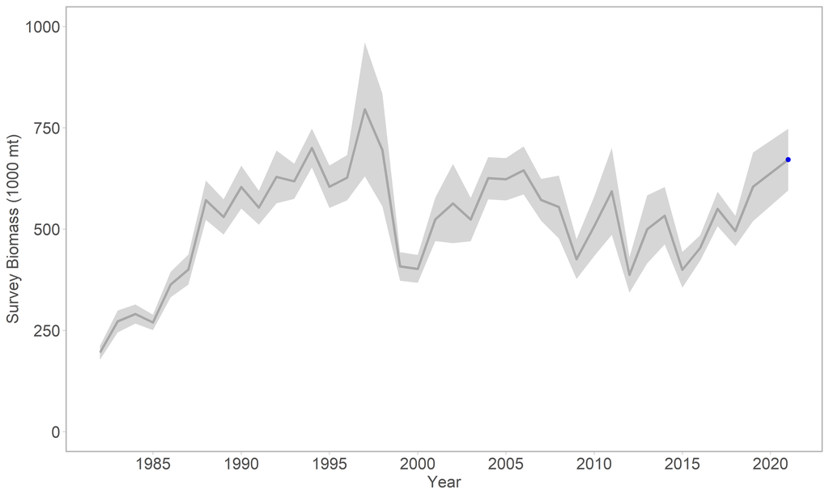

**Figure 2**. Survey biomass from the EBS shelf and Aleutian Islands surveys for station depths less than or equal to 200 meters. A linear regression is used to estimate a relationship between EBS shelf *Hippoglossoides spp.* survey biomass estimates and AI survey biomass estimates; this relationship is used to estimate AI survey biomass in years when no AI survey occurred (by using the linear equation to find an AI biomass estimate in a particular year based on the EBS biomass estimate for that year). Grey shading indicates ± 1 standard error. The blue point was the observed survey biomass in 2021, which is not included in the base assessment model.